# Demonstrating Brute Force Fit

Bill Prisbrey

2025-10-21

**PURPOSE:** The purpose of this report is to describe an effort to accurately calculate University headcount using an algorithm that I am calling a “brute force fit.”

**OBJECTIVES:** (1) Describe the problem and the resolution path.  
(2) Explain possible next steps.  
(3) Show the breakdown of the population by entry and exit actions.  
(4) Show examples of individual journeys from various sub-sets of the population with the blue line that is the “force-fit” approximation.  
(5) Show the resulting headcount estimation since 2010.

**MEETING NOTES, 10/23/2025:**

Attendance: Kirsten Allen, Brian Gelsinger, David Howell, Bill Prisbrey

Action Items:

- Brian will provide a SQL query that will provide a list of EMPLIDs and basic fields like department or college on snapshot dates (Jan/July) going back five to ten years. Estimated completion date of Friday 10/31/2025.
- Bill will proceed with the next steps, including using the snapshot data as a validation data set, focusing on the chemical engineering department.

Notes:

### Problem and resolution path explained

**ISSUE:** An accurate headcount is critical to analyzing turnover. Turnover is usually calculated as a rate, or as the number of employees departing divided by the headcount.

**DIFFICULTY:** Calculating the headcount for employees who have one job a time is straight-forward: they are added to the headcount when they are hired and subtracted when they leave.

However, many employees at the University of Utah hold concurrent positions. Each position will have its own actions possibly affecting headcount: one position will be terminated, but not the other; or one will commence a work break and not the other. This already-complex record may have been further muddied by inconsistent record-keeping over time and across departments.

These concurrent positions do not have distinct identifiers in the database. An employee may start with one position, add a second, and then quit the first. The identifier of the second position will be changed to match the identifier of the first.

Accurately tallying headcount for these employees is challenging. They are easily double-counted or double-deducted from the headcount.

**RESOLUTION:**

Each employee is considered one at a time, and the following algorithm is applied:

- Every “entry” action increases the cumulative headcount.
- Every “exit” action decreases the cumulative headcount.
- Because an employee is considered one at a time, a headcount value greater than one or less than zero is not allowed.
- A “university-level” boundary date can then be extracted per individual.

### Next steps

*(1) Validate and verify.* Although this method produces an internally-consistent data set, where the number of entries does not exceed the number of exits for example, additional validation is sought.

*(2) Add transfer events.* Employees frequently transfer between positions, titles, and departments. Adding transfer events will improve the granularity of the analysis.

*(3) Include transfers to unpaid positions as ‘exit’ boundary events.* Many employees are never terminated but are transferred to volunteer positions. It may be desirable to exclude these individuals from a headcount tally.

### Population breakdown by journey characteristics

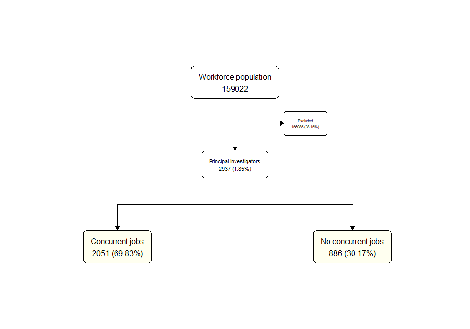

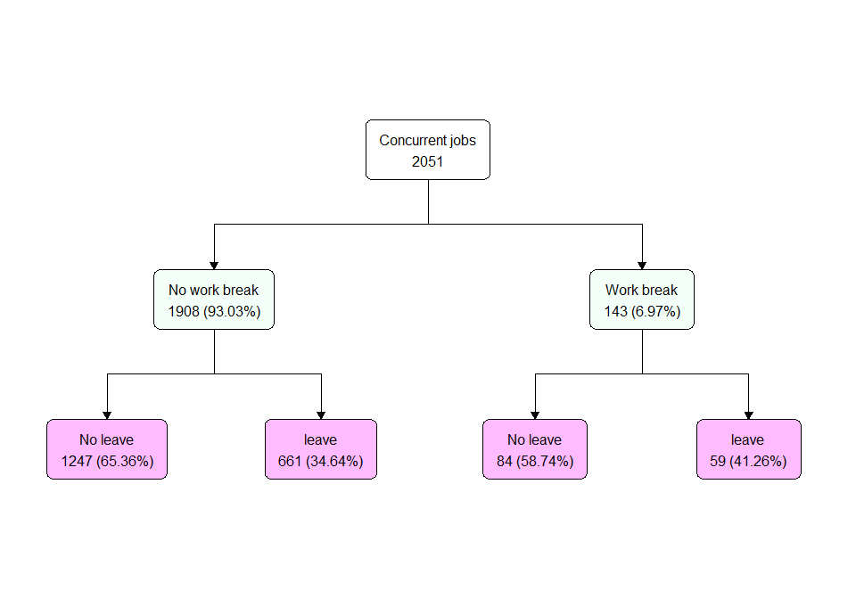

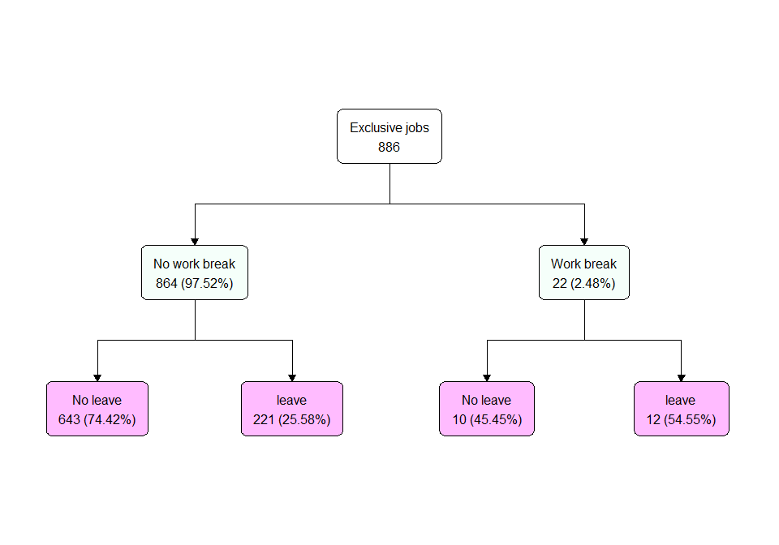

### Individual journeys

#### **EXCLUSIVE JOURNEY**

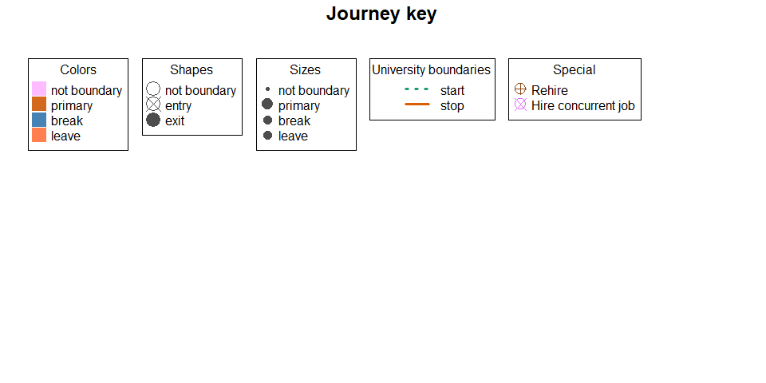

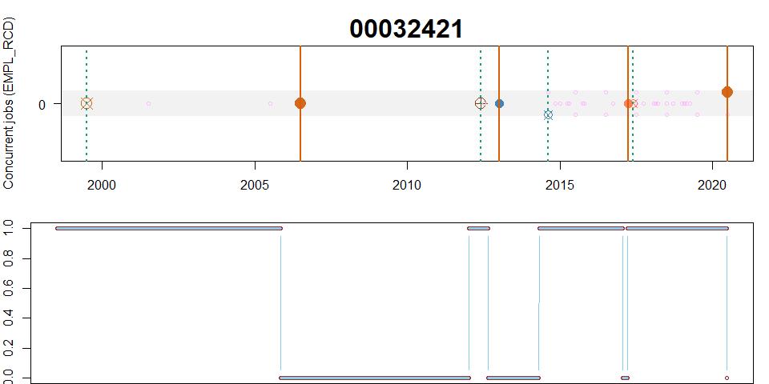

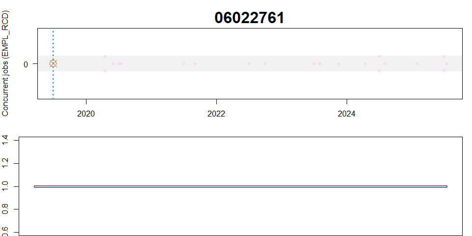

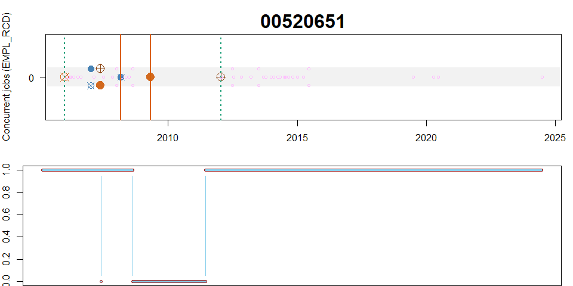

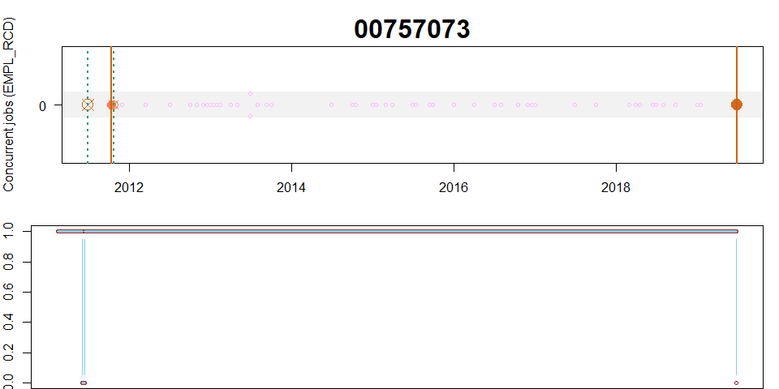

#### **CONCURRENT JOURNEY**

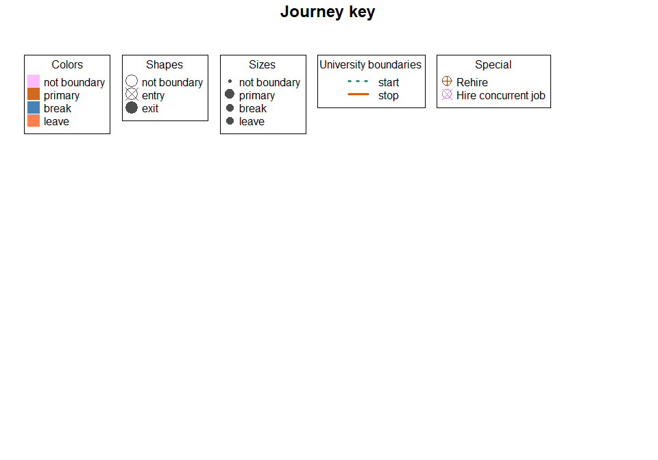

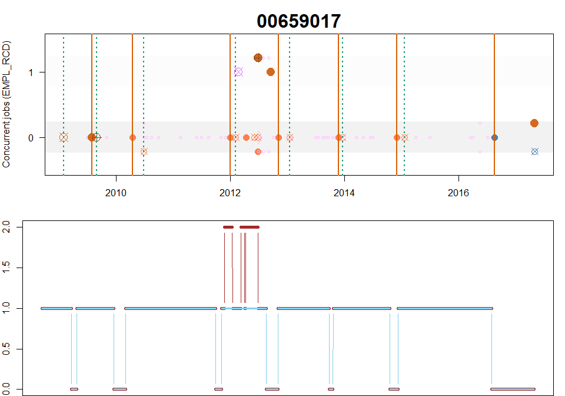

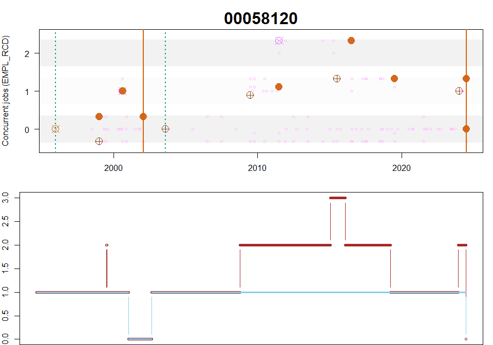

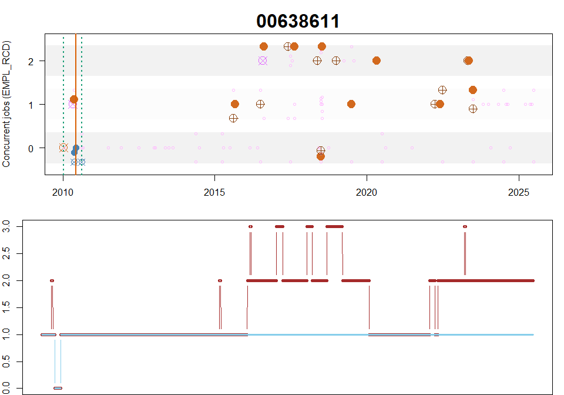

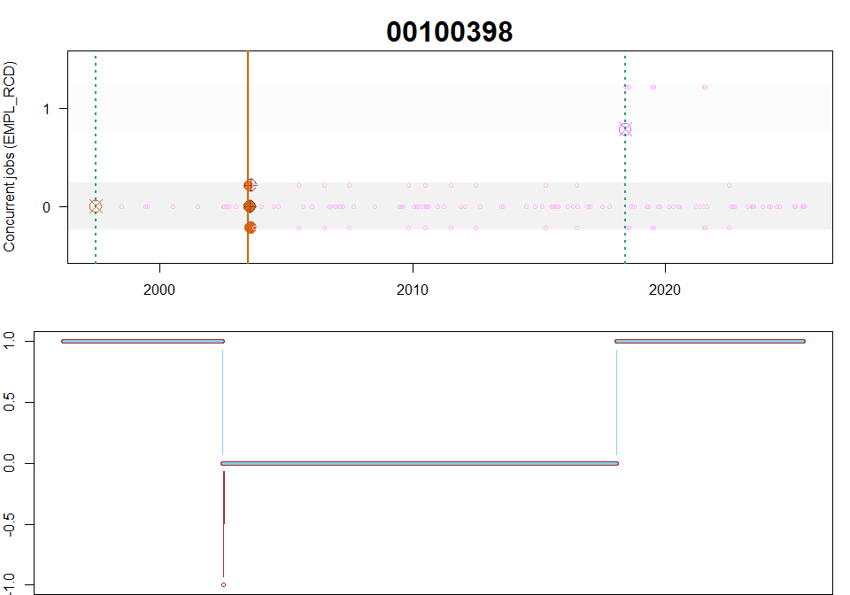

### Headcount Metrics

#### **EXCLUSIVE JOBS**

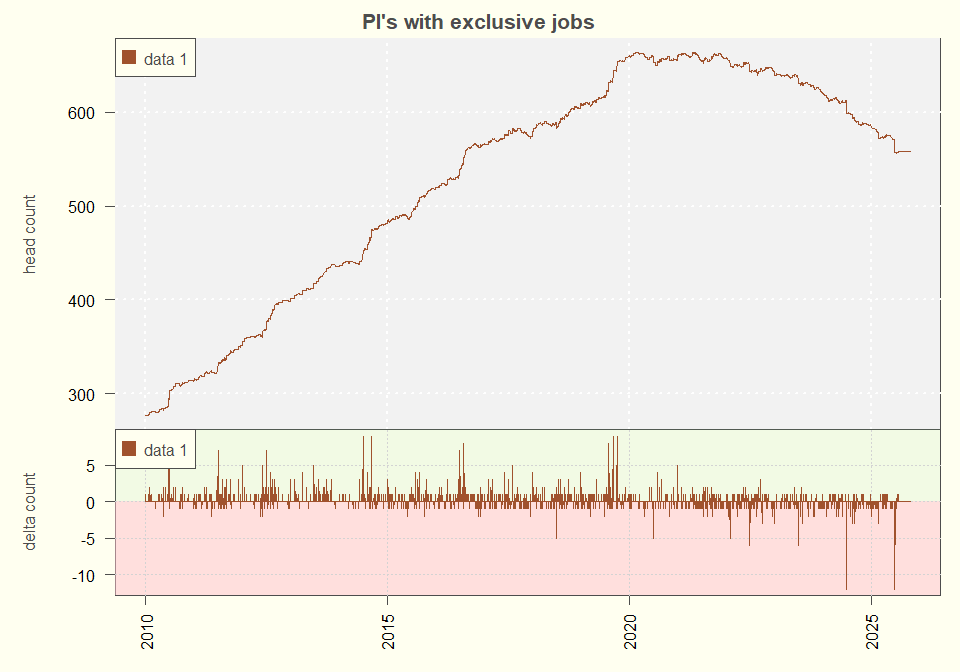

#### **CONCURRENT JOBS**

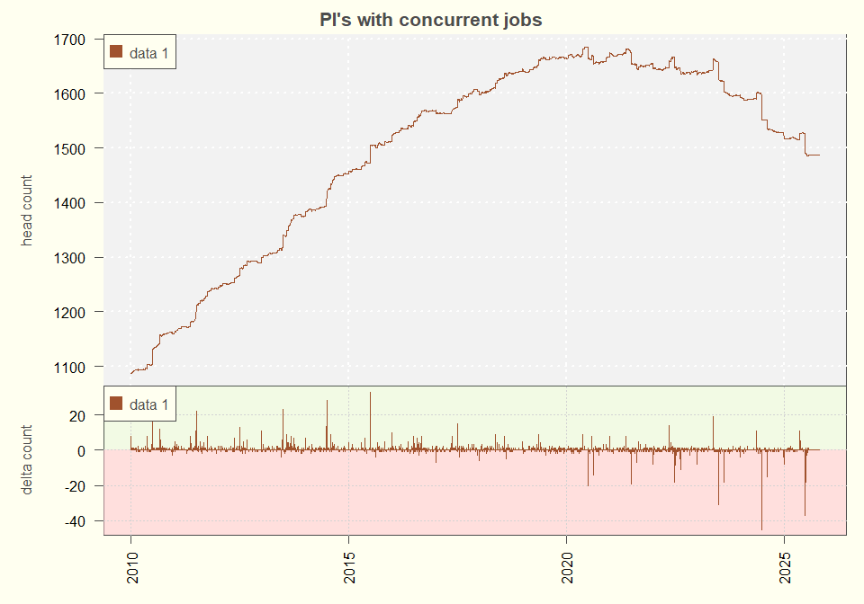

#### **FULL POPULATION**

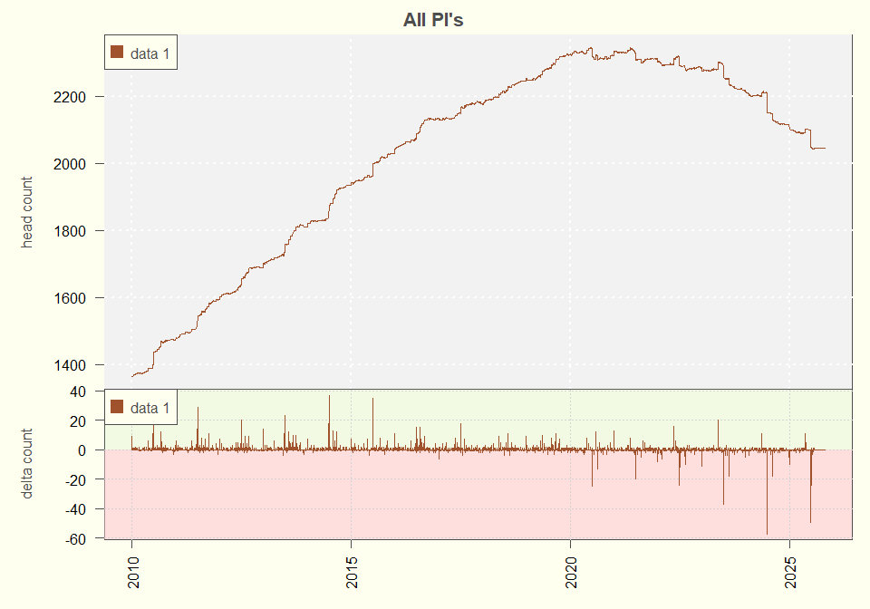

### Explain HeadCount

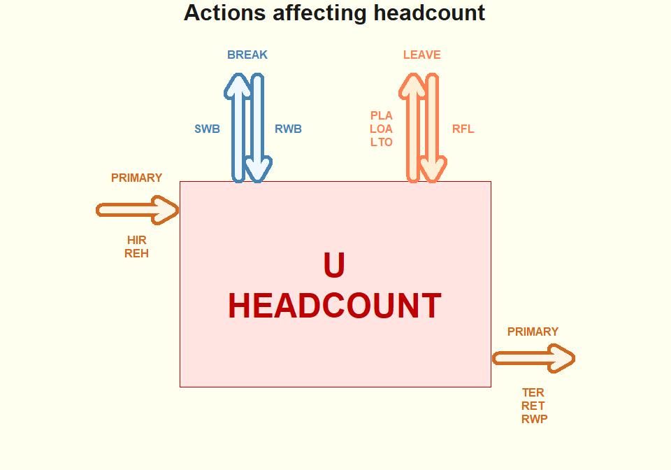

‘Exit’ condition needs to be modified to accommodate the transfer to volunteer positions

*Per Brian Gelsinger, Teams message on 14 Oct 2025:*